# EDA

Rylan Tribush

2024-10-06

# Introduction

### The Business Problem

Swire Coca-Cola operates six facilities that produce approximately 192 million cases of beverages annually. However, the plants experience a production shortfall, producing only 94.4% of the total intended cases due to unplanned mechanical breakdowns and maintenance issues. This gap, costing the company approximately $60 million in lost productivity annually, results from unanticipated downtimes caused by machinery failures across various production lines. The current process relies on reactive maintenance through an Internal Warehouse Controller (IWC) system, which issues work orders only after machinery failures occur, leading to significant delays in repairs and downtime.

A predictive maintenance solution would allow Swire Coca-Cola to anticipate and mitigate these downtimes. By predicting when and why machinery failures are likely to occur, the company can schedule proactive maintenance, reduce unplanned downtimes, increase production efficiency, and save millions annually. In addition, such a system would help Swire Coca-Cola maintain optimal production levels to meet demand and reduce maintenance costs by ensuring parts are stocked in advance.

### The Analytics Problem

To address the business problem, Swire Coca-Cola needs to analyze downtime records from its Internal Warehouse Controller (IWC) system. The objective is to identify patterns and causes of unplanned downtimes and develop a predictive maintenance model. The company has been collecting data for a while, but up until now has not been using the data effectively. By leveraging internal data generated from the IWC system, the predictive model will minimize downtime, improve output efficiency, and ultimately increase profits for the company.

### Our Goals for this Notebook

The goal of this notebook is to thoroughly explore machine downtime dataset that Swire Coca-Cola has created. This exploration will help us answer the following questions:

1. What are the basic characteristics of the dataset?
2. Are there missing values or data quality issues?
3. What is the distribution of each variable?
4. Are there correlations between variables?
5. What patterns or trends emerge?

# Description of the Data

Before looking at any of the data, it is important to have a basic understanding of the variables. Reproduced below is a copy of the data dictionary.

| Variable Name | Description |
| --- | --- |
| ORDER_ID | An identifier used to uniquely map every order raised in IWC |
| PLANT_ID | Helps uniquely identify all factories of Swire Coca-Cola, between Monza, Cota, Silverstone, Monaco, Roma and Suzuka |
| PRODUCTION_LOCATION | Text description of Plant_ID |
| EXECUTION_START_DATE | The date on which work began on the said issue |
| EXECUTION_FINISH_DATE | The date on which work ended to resolve said issue |
| ACTUAL_START_TIME | The time at which work began on resolving said issue* |
| ACTUAL_FINISH_TIME | The time at which work ended on resolving said issue* |
| ACTUAL_WORK_IN_MINUTES | The time it took, in minutes, to resolve said issue* |
| MAINTENANCE_PLAN | If the maintenance task was planned, this would have the plan ID. If this column is null, that implies that the maintenance was unplanned |
| MAINTENANCE_ITEM | If the maintenance task was planned, for example, this bearing needs to be changed every six weeks, then the plan in the IWC system will have code allocated to it, saying this bearing code a maintenan… |
| MAINTENANCE_ACTIVITY_TYPE | Lets you know if the maintenance was planned or unplanned, as an additional flag |
| ORDER_DESCRIPTION | The description entered by the mechanic as to what was the actual work that was carried out in said fix |
| MAINTENANCE_TYPE_DESCRIPTION | Tells you if the work order was preventive in nature, i.e. done to prevent breakdowns in future, or corrective in nature, i.e. done to correct something that caused a downtime |
| FUNCTIONAL_LOC | Works like an IP address. Helps locate each machine by plant – process – sub process – product line – machine. Is broken down into nodes for better analysis |
| FUNCTIONAL_AREA_NODE_1_MODIFIED | The functional area within said plant – Production, fleet, HVAC, etc. |
| FUNCTIONAL_AREA_NODE_2_MODIFIED | The region-based subset of the functional area – Is it the blender room, the assembly lines – can, bottle or bibs |
| FUNCTIONAL_AREA_NODE_3_MODIFIED | Within each region, which subset of equipment does this work order belong to |
| FUNCTIONAL_AREA_NODE_4_MODIFIED | Within line groupings, which line is it specifically referring to – contains line number |
| FUNCTIONAL_AREA_NODE_5_MODIFIED | Further splits the line into individual machine types |
| EQUIPMENT_ID | Within a filler, there are close to 60 smaller components. This will help us identify which component the work was done on within that filler, for example |
| EQUIPMENT_DESC5 | Helps us identify what that component is. Mind you, we won’t always have a description because some components are either too small to be classified or proprietary and hence undisclosed |
| EQUIPMENT_CAT_DESC | Identifies if the fixed part was on a machine, a vehicle, an HVAC system, etc. |
| EQUIP_START_UP_DATE | The date on which this machine was acquired ** |
| EQUIP_VALID_FROM | The date on which this machine became functional ** |
| EQUIP_VALID_TO | The date until which this machine shall be used ** |

```r
# load data from csv file
df <- read_csv("IWC_Work_Orders_Extract.csv")
```

```r
# show the number of rows and columns
df %>%
  dim()
```

```
## [1] 1427264      25
```

```r
# structure of data
df %>%
  str()
```

```
## spc_tbl_ [1,427,264 × 25] (S3: spec_tbl_df/tbl_df/tbl/data.frame)
##  $ ORDER_ID                       : num [1:1427264] 7.06e+08 7.04e+08 7.04e+08 7.04e+08 7.05e+08 ...
##  $ PLANT_ID                       : chr [1:1427264] "G812" "G812" "G812" "G812" ...
##  $ PRODUCTION_LOCATION            : chr [1:1427264] "ROMA" "ROMA" "ROMA" "ROMA" ...
##  $ EXECUTION_START_DATE           : Date[1:1427264], format: "2024-05-04" "2022-09-13" ...
##  $ EXECUTION_FINISH_DATE          : Date[1:1427264], format: "2024-05-12" "2022-09-13" ...
##  $ ACTUAL_START_TIME              : 'hms' num [1:1427264] 06:00:00 06:00:00 07:00:00 06:00:00 ...
##   ..- attr(*, "units")= chr "secs"
##  $ ACTUAL_FINISH_TIME             : 'hms' num [1:1427264] 23:04:08 17:17:24 07:00:00 06:00:00 ...
##   ..- attr(*, "units")= chr "secs"
##  $ ACTUAL_WORK_IN_MINUTES         : num [1:1427264] 390 420 30 60 120 18 480 30 30 30 ...
##  $ MAINTENANCE_PLAN               : chr [1:1427264] NA NA NA NA ...
##  $ MAINTENANCE_ITEM               : chr [1:1427264] NA NA NA NA ...
##  $ MAINTENANCE_ACTIVITY_TYPE      : chr [1:1427264] "Unplanned" "Unplanned" "Unplanned" "Unplanned" ...
##  $ ORDER_DESCRIPTION              : chr [1:1427264] "L2 GEARBOX LEAK (SEE ATTACHED)" "LINE 3 CONVEYOR AT CAN CODER" "BROKEN CONVEYOR RAIL" "LINE 3 CONVEYOR" ...
##  $ MAINTENANCE_TYPE_DESCRIPTION   : chr [1:1427264] "Corrective Maintenance Order" "Corrective Maintenance Order" "Corrective Maintenance Order" "Corrective Maintenance Order" ...
##  $ FUNCTIONAL_LOC                 : chr [1:1427264] "G812-PRD-L15-L03-L030-020" "G812-PRD-L15-L03-L030-020" "G812-PRD-L15-L03-L030-020" "G812-PRD-L15-L03-L030-020" ...
##  $ FUNCTIONAL_AREA_NODE_1_MODIFIED: chr [1:1427264] "PRODUCTION" "PRODUCTION" "PRODUCTION" "PRODUCTION" ...
##  $ FUNCTIONAL_AREA_NODE_2_MODIFIED: chr [1:1427264] "G812 PRD FILLER_ROTARY_CAN" "G812 PRD FILLER_ROTARY_CAN" "G812 PRD FILLER_ROTARY_CAN" "G812 PRD FILLER_ROTARY_CAN" ...
##  $ FUNCTIONAL_AREA_NODE_3_MODIFIED: chr [1:1427264] "G812 PRD FILLER_ROTARY_CAN LINE 3" "G812 PRD FILLER_ROTARY_CAN LINE 3" "G812 PRD FILLER_ROTARY_CAN LINE 3" "G812 PRD FILLER_ROTARY_CAN LINE 3" ...
##  $ FUNCTIONAL_AREA_NODE_4_MODIFIED: chr [1:1427264] "CONVEYOR" "CONVEYOR" "CONVEYOR" "CONVEYOR" ...
##  $ FUNCTIONAL_AREA_NODE_5_MODIFIED: chr [1:1427264] "FULL CAN CONVEYOR" "FULL CAN CONVEYOR" "FULL CAN CONVEYOR" "FULL CAN CONVEYOR" ...
##  $ EQUIPMENT_ID                   : chr [1:1427264] "000000000300126812" "000000000300126812" "000000000300126812" "000000000300126812" ...
##  $ EQUIPMENT_DESC                 : chr [1:1427264] "FULL CAN CONVEYOR (FC41B)" "FULL CAN CONVEYOR (FC41B)" "FULL CAN CONVEYOR (FC41B)" "FULL CAN CONVEYOR (FC41B)" ...
##  $ EQUIP_CAT_DESC                 : chr [1:1427264] "Machines" "Machines" "Machines" "Machines" ...
##  $ EQUIP_START_UP_DATE            : Date[1:1427264], format: "2020-04-22" "2020-04-22" ...
##  $ EQUIP_VALID_FROM               : Date[1:1427264], format: "2020-02-10" "2020-02-10" ...
##  $ EQUIP_VALID_TO                 : Date[1:1427264], format: "9999-12-31" "9999-12-31" ...
##  - attr(*, "spec")=
##   .. cols(
##   ..   ORDER_ID = col_double(),
##   ..   PLANT_ID = col_character(),
##   ..   PRODUCTION_LOCATION = col_character(),
##   ..   EXECUTION_START_DATE = col_date(format = ""),
##   ..   EXECUTION_FINISH_DATE = col_date(format = ""),
##   ..   ACTUAL_START_TIME = col_time(format = ""),
##   ..   ACTUAL_FINISH_TIME = col_time(format = ""),
##   ..   ACTUAL_WORK_IN_MINUTES = col_double(),
##   ..   MAINTENANCE_PLAN = col_character(),
##   ..   MAINTENANCE_ITEM = col_character(),
##   ..   MAINTENANCE_ACTIVITY_TYPE = col_character(),
##   ..   ORDER_DESCRIPTION = col_character(),
##   ..   MAINTENANCE_TYPE_DESCRIPTION = col_character(),
##   ..   FUNCTIONAL_LOC = col_character(),
##   ..   FUNCTIONAL_AREA_NODE_1_MODIFIED = col_character(),
##   ..   FUNCTIONAL_AREA_NODE_2_MODIFIED = col_character(),
##   ..   FUNCTIONAL_AREA_NODE_3_MODIFIED = col_character(),
##   ..   FUNCTIONAL_AREA_NODE_4_MODIFIED = col_character(),
##   ..   FUNCTIONAL_AREA_NODE_5_MODIFIED = col_character(),
##   ..   EQUIPMENT_ID = col_character(),
##   ..   EQUIPMENT_DESC = col_character(),
##   ..   EQUIP_CAT_DESC = col_character(),
##   ..   EQUIP_START_UP_DATE = col_date(format = ""),
##   ..   EQUIP_VALID_FROM = col_date(format = ""),
##   ..   EQUIP_VALID_TO = col_date(format = "")
##   .. )
##  - attr(*, "problems")=<externalptr>
```

```r
# summary of the data
df %>%
  summary()
```

```
##     ORDER_ID           PLANT_ID         PRODUCTION_LOCATION
##  Min.   :1.000e+08   Length:1427264     Length:1427264
##  1st Qu.:4.023e+08   Class :character   Class :character
##  Median :7.044e+08   Mode  :character   Mode  :character
##  Mean   :4.561e+10
##  3rd Qu.:1.002e+09
##  Max.   :9.000e+11
##
##  EXECUTION_START_DATE EXECUTION_FINISH_DATE ACTUAL_START_TIME
##  Min.   :2013-08-19   Min.   :2016-07-25    Length:1427264
##  1st Qu.:2019-02-09   1st Qu.:2019-02-11    Class1:hms
##  Median :2020-12-09   Median :2020-12-10    Class2:difftime
##  Mean   :2020-12-20   Mean   :2020-12-21    Mode  :numeric
##  3rd Qu.:2022-12-07   3rd Qu.:2022-12-08
##  Max.   :2024-08-30   Max.   :2024-08-30
##
##  ACTUAL_FINISH_TIME ACTUAL_WORK_IN_MINUTES MAINTENANCE_PLAN
##  Length:1427264     Min.   :     0.0       Length:1427264
##  Class1:hms         1st Qu.:    12.0       Class :character
##  Class2:difftime    Median :    48.0       Mode  :character
##  Mode  :numeric     Mean   :    88.6
##                     3rd Qu.:    90.0
##                     Max.   :330184.8
##
##  MAINTENANCE_ITEM   MAINTENANCE_ACTIVITY_TYPE ORDER_DESCRIPTION
##  Length:1427264     Length:1427264            Length:1427264
##  Class :character   Class :character          Class :character
##  Mode  :character   Mode  :character          Mode  :character
##
##
##
##
##  MAINTENANCE_TYPE_DESCRIPTION FUNCTIONAL_LOC
##  Length:1427264               Length:1427264
##  Class :character             Class :character
##  Mode  :character             Mode  :character
##
##
##
##
```

[output cut: 25 more lines]

```
##  Length:1427264     Min.   :1960-01-01   Min.   :2017-02-15
##  Class :character   1st Qu.:2017-02-15   1st Qu.:2017-02-15
##  Mode  :character   Median :2017-02-15   Median :2017-03-15
##                     Mean   :2017-06-19   Mean   :2019-03-03
##                     3rd Qu.:2018-05-07   3rd Qu.:2020-08-11
##                     Max.   :2024-05-16   Max.   :2024-05-20
##                     NA's   :1347817      NA's   :1347817
##  EQUIP_VALID_TO
##  Min.   :9999-12-31
##  1st Qu.:9999-12-31
##  Median :9999-12-31
##  Mean   :9999-12-31
##  3rd Qu.:9999-12-31
##  Max.   :9999-12-31
##  NA's   :1347817
```

# Discussion of Missing Data

```r
# show the number of NAs in the dataset
df %>%
  is.na() %>%
  sum()
```

```
## [1] 19895694
```

```r
# calculate the percentage of missing data
(sum(is.na(df)) / (nrow(df) * ncol(df)) * 100) %>%
  round(2)
```

```
## [1] 55.76
```

```r
# show the number of NAs for each column
colSums(is.na(df))
```

```
##                        ORDER_ID                        PLANT_ID
##                               0                               0
##             PRODUCTION_LOCATION            EXECUTION_START_DATE
##                               0                               0
##           EXECUTION_FINISH_DATE               ACTUAL_START_TIME
##                               0                               0
##              ACTUAL_FINISH_TIME          ACTUAL_WORK_IN_MINUTES
##                               0                               0
##                MAINTENANCE_PLAN                MAINTENANCE_ITEM
##                         1274670                         1274670
##       MAINTENANCE_ACTIVITY_TYPE               ORDER_DESCRIPTION
##                               0                         1135497
##    MAINTENANCE_TYPE_DESCRIPTION                  FUNCTIONAL_LOC
##                         1135469                         1135482
## FUNCTIONAL_AREA_NODE_1_MODIFIED FUNCTIONAL_AREA_NODE_2_MODIFIED
##                         1137147                         1144857
## FUNCTIONAL_AREA_NODE_3_MODIFIED FUNCTIONAL_AREA_NODE_4_MODIFIED
##                         1168573                         1189691
## FUNCTIONAL_AREA_NODE_5_MODIFIED                    EQUIPMENT_ID
##                         1425084                         1135469
##                  EQUIPMENT_DESC                  EQUIP_CAT_DESC
##                         1347817                         1347817
##             EQUIP_START_UP_DATE                EQUIP_VALID_FROM
##                         1347817                         1347817
##                  EQUIP_VALID_TO
##                         1347817
```

```r
# show the percentage of NAs for each column
colSums(is.na(df)) / nrow(df)
```

```
##                        ORDER_ID                        PLANT_ID
##                       0.0000000                       0.0000000
##             PRODUCTION_LOCATION            EXECUTION_START_DATE
##                       0.0000000                       0.0000000
##           EXECUTION_FINISH_DATE               ACTUAL_START_TIME
##                       0.0000000                       0.0000000
##              ACTUAL_FINISH_TIME          ACTUAL_WORK_IN_MINUTES
##                       0.0000000                       0.0000000
##                MAINTENANCE_PLAN                MAINTENANCE_ITEM
##                       0.8930864                       0.8930864
##       MAINTENANCE_ACTIVITY_TYPE               ORDER_DESCRIPTION
##                       0.0000000                       0.7955760
##    MAINTENANCE_TYPE_DESCRIPTION                  FUNCTIONAL_LOC
##                       0.7955564                       0.7955655
## FUNCTIONAL_AREA_NODE_1_MODIFIED FUNCTIONAL_AREA_NODE_2_MODIFIED
##                       0.7967321                       0.8021340
## FUNCTIONAL_AREA_NODE_3_MODIFIED FUNCTIONAL_AREA_NODE_4_MODIFIED
##                       0.8187504                       0.8335466
## FUNCTIONAL_AREA_NODE_5_MODIFIED                    EQUIPMENT_ID
##                       0.9984726                       0.7955564
##                  EQUIPMENT_DESC                  EQUIP_CAT_DESC
##                       0.9443362                       0.9443362
##             EQUIP_START_UP_DATE                EQUIP_VALID_FROM
##                       0.9443362                       0.9443362
##                  EQUIP_VALID_TO
##                       0.9443362
```

There is a lot of missing data, which will make our analysis difficult. Additionally, the variables that we do have may not translate well to a predictive model.

# Exploratory Visualizations and Summary Tables

```r
# frequency tables for categorical variables
table(df$PLANT_ID)
```

```
##
##   G221   G261   G291   G811   G812   G816
## 290975 630903 225279  84694  79110 116303
```

```r
table(df$PRODUCTION_LOCATION)
```

```
##
##        COTA      MONACO       MONZA        ROMA SILVERSTONE      SUZUKA
##      116303       84694      225279       79110      630903      290975
```

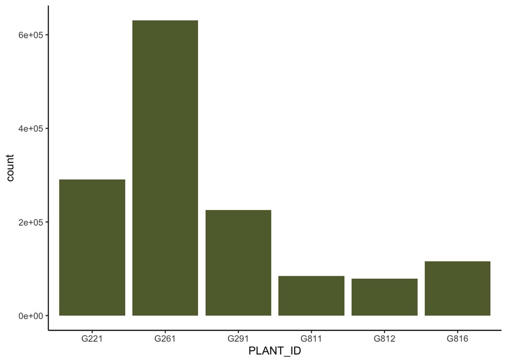

```r
ggplot(df, aes(PLANT_ID)) +
  geom_bar(fill = "#606c38") +
  theme_classic()
```

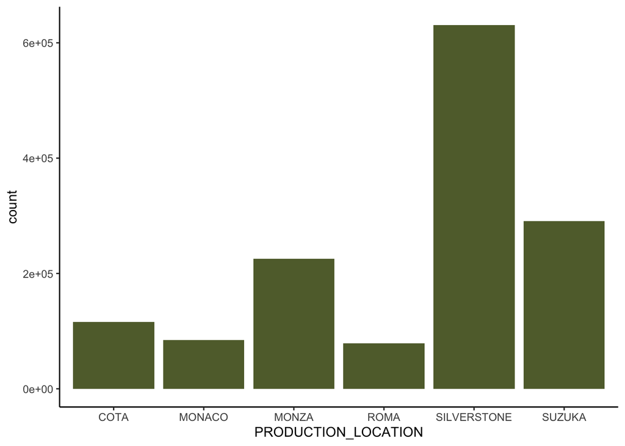

```r
ggplot(df, aes(PRODUCTION_LOCATION)) +
  geom_bar(fill = "#606c38") +
  theme_classic()
```

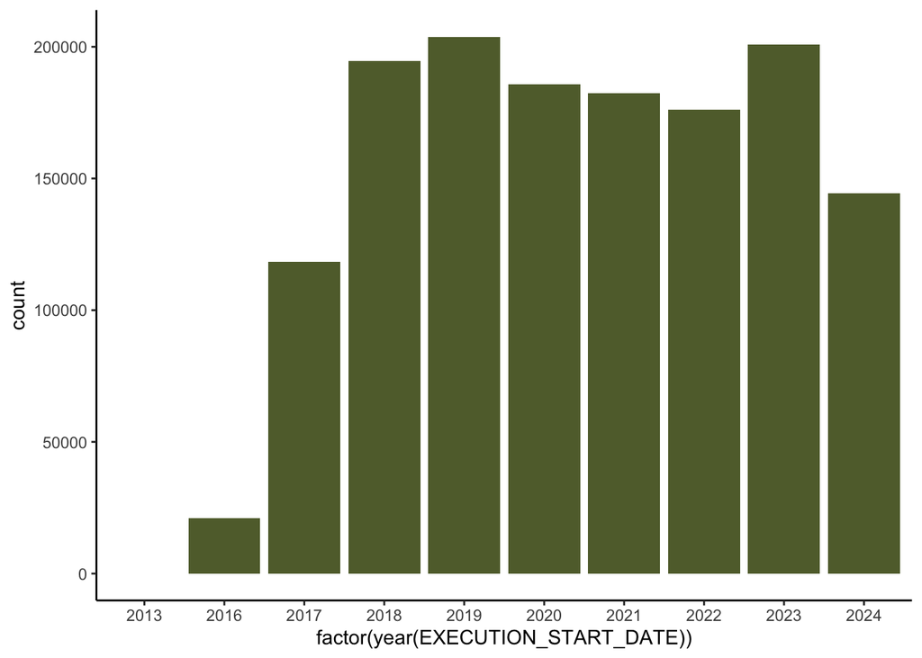

```r
ggplot(df, aes(factor(year(EXECUTION_START_DATE)))) +
  geom_bar(fill = "#606c38") +
  theme_classic()
```

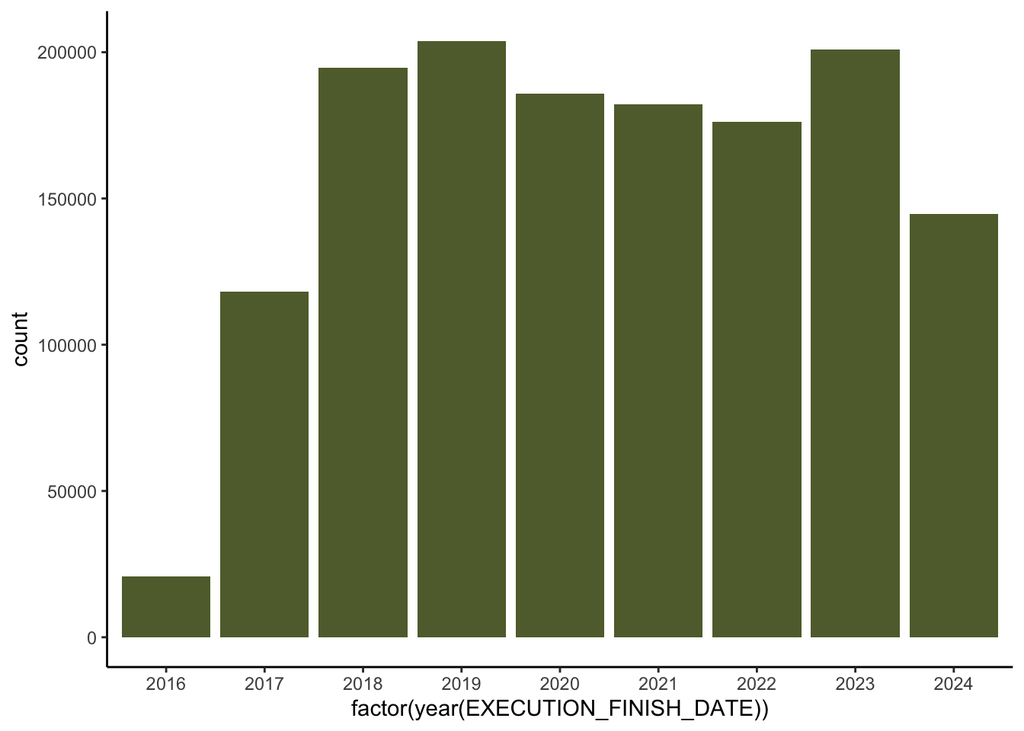

```r
ggplot(df, aes(factor(year(EXECUTION_FINISH_DATE)))) +
  geom_bar(fill = "#606c38") +
  theme_classic()
```

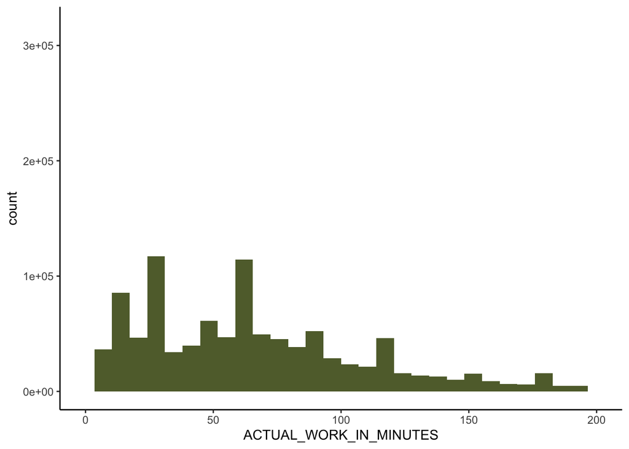

```r
ggplot(df, aes(ACTUAL_WORK_IN_MINUTES)) +
  geom_histogram(fill = "#606c38") +
  theme_classic() +
  xlim(c(0, 200))
```